# Notebook

### Фактический запуск 14.09.2026

Все вычислительные ячейки выполнены. Техническое исполнение не подтверждает научные интерпретации исторического текста. Полный журнал — `legacy-execution.json`.

## Статус воспроизведения исторической редакции

Повторный технический запуск не подтверждает научные выводы старой редакции. Ниже сохранены прежние допущения и интерпретации; их следует сверять с текущими правилами проекта. Дыхательная и ЭКГ-разметка исторических расчётов не получает статус принятой при повторном запуске. Значения толщины 15 и 40 мм — исторические сценарии, а не заново проверенные измерения по КТ. Старые оценки сердечного происхождения сигнала и функций сердца не считаются валидированными.

```
Исторические входы скопированы; запись в исходные метки и параметры исключена.
```

# Указатель происхождения: 10_КТ_оценка_HU.ipynb

> **Статус:** санифицированный указатель, а не копия исходного расчёта.
- Исходный путь: Colab Notebooks/10_КТ_оценка_HU.ipynb.
- Исходный коммит: 1ac7813654b59861e359cffe3ad40941baeab2d9.
- Последняя объединённая активная версия перед разделением восстанавливается из 20.01_DICOM_QC_и_геометрия_тома.ipynb в коммите fff4d3a.
- Контрольные суммы и ID ячеек находятся в ../../MIGRATION_MANIFEST_2026-08-26.json.
- Текущие владельцы функций: DICOM-QC — ../../20.01_DICOM_QC_и_геометрия_тома.ipynb; регистрация ручных масок Inobitec и электродов — ../../20.02_Регистрация_Inobitec_и_электродов.ipynb; HU и доля воздуха — ../../20.03_HU_и_доля_воздуха_в_лёгком.ipynb; электрические сценарии — ../../20.04_Сценарии_электрических_свойств_лёгкого.ipynb.
- Пороговая сегментация остаётся только историческим методом. Она не заменяет каноническую ручную сегментацию Inobitec.

Файл не содержит старых outputs, локальных путей или субъектно-связанных значений. Для восстановления исходной версии необходимо использовать Git-коммит и манифест. Этот указатель нельзя читать как вход активного расчёта.

# Оценка среднего HU лёгкого по КТ → ρ₂ (модель смешивания, §3)

Автоматическая сверка (без ручного просмотра срезов). Для каждого испытуемого:

1. из набора DICOM-серий выбирается **STD** (стандартное ядро, без контраста — лучшее для количественного HU);
2. лёгкое сегментируется **по порогу HU** (не зависит от ручной сегментации Inobitec);
3. берётся **нижняя треть правого лёгкого** (зона наложения сборок) → средний HU;
4. HU → доля воздуха `f` (ур. 9) → `ρ₂` по Максвеллу–Гарнетту и Арчи (ур. 10) с разверткой по `ρ_матр`;
5. сравнение с ρ₂ из обратной задачи (`09_Статическая_оценка_параметров.ipynb`).

КТ — кардио, на задержке вдоха → сравниваем с ρ₂_вд. h берём измеренным (15/40 мм), по КТ не пересчитываем.

## §0. Методика КТ-оценки удельного сопротивления лёгкого и словарь терминов

### Решаемая задача

Требуется независимо от импеданса оценить удельное электрическое сопротивление лёгкого ρ₂ по компьютерной томографии и сверить его с оценкой из обратной задачи (09). Это внешняя перекрёстная проверка двуслойной модели: томография и импеданс — независимые источники, и их согласие подтверждает модель.

### Метод и обоснование выбора

Лёгкое рассматривается как смесь воздуха (изолятора) и проводящей матрицы (ткань, кровь, вода). По томографии определяется объёмная доля воздуха, затем по модели смешивания вычисляется удельное сопротивление. Метод выбран потому, что томография даёт независимый от электрических измерений эталон, а доля воздуха напрямую связана с рентгеновской плотностью.

### Словарь терминов

- **Компьютерная томография** — метод рентгеновской визуализации, дающий трёхмерное распределение рентгеновской плотности.
- **Шкала Хаунсфилда** (HU, Hounsfield units — единицы Хаунсфилда) — калиброванная шкала рентгеновской плотности: воздух соответствует −1000, вода — 0 ([вторичный источник](https://ru.wikipedia.org/wiki/%D0%A8%D0%BA%D0%B0%D0%BB%D0%B0_%D0%A5%D0%B0%D1%83%D0%BD%D1%81%D1%84%D0%B8%D0%BB%D0%B4%D0%B0)).
- **Объёмная доля воздуха** f — доля объёма ткани, занятая воздухом; определяется по плотности в шкале Хаунсфилда.
- **Проводящая матрица** — часть лёгкого без воздуха (ткань, кровь, вода); её удельное сопротивление ρ_матр — параметр модели смешивания, задаётся из литературы.
- **Модель смешивания Максвелла–Гарнетта** — формула эффективного удельного сопротивления среды с изолирующими включениями заданной объёмной доли ([вторичный источник](https://ru.wikipedia.org/wiki/%D0%9F%D1%80%D0%B8%D0%B1%D0%BB%D0%B8%D0%B6%D0%B5%D0%BD%D0%B8%D0%B5_%D0%9C%D0%B0%D0%BA%D1%81%D0%B2%D0%B5%D0%BB%D0%BB%D0%B0_%D0%93%D0%B0%D1%80%D0%BD%D0%B5%D1%82%D1%82%D0%B0)).
- **Серия STD** — реконструкция томографического объёма стандартным ядром без контрастирования; выбирается автоматически.
- **Нижняя треть правого лёгкого** — область под электродными сборками, по которой усредняется рентгеновская плотность.

### Формулы

Объёмная доля воздуха по рентгеновской плотности, формула (10.1):

$$f=\frac{HU_{\text{ткань}}-HU}{HU_{\text{ткань}}-HU_{\text{возд}}}\ \xrightarrow{\ HU_{\text{ткань}}\approx0,\ HU_{\text{возд}}=-1000\ }\ f\approx\frac{-HU}{1000} \tag{10.1}$$

где f — объёмная доля воздуха, безразмерная; HU — измеренная рентгеновская плотность области, единицы Хаунсфилда; HU_ткань, HU_возд — плотность ткани и воздуха.

Удельное сопротивление по модели смешивания Максвелла–Гарнетта, формула (10.2):

$$\rho_2=\rho_{\text{матр}}\,\frac{1+f/2}{1-f} \tag{10.2}$$

где ρ₂ — удельное сопротивление лёгкого, Ом·м; ρ_матр — удельное сопротивление проводящей матрицы, Ом·м; f — объёмная доля воздуха.

### Как оценивать результаты

Оценка ρ₂ по томографии сравнивается с оценкой из обратной задачи (09). Совпадение без подгонки подтверждает двуслойную модель; результат линейно зависит от принятого ρ_матр, поэтому это значение фиксируется явно.

**Входные данные.** Пути к томографическим данным обоих испытуемых; выбираемая серия STD; удельное сопротивление проводящей матрицы ρ_матр = 2.5 Ом·м; пороги плотности лёгкого; толщина слоя мягких тканей (Ник 15 мм, Георгий 40 мм).

**Допущения.** Проводящая матрица (ткань с кровью) принимается с удельным сопротивлением 2.5 Ом·м по литературе; результат (10.2) линейно зависит от этого значения, поэтому оно задаётся явно. Выбирается серия STD, так как она без контрастирования и со стандартным ядром реконструкции.

```
Серия: {'Ник': 'STD', 'Георгий': 'STD'} | SLICE_STEP = 4
```

**Анализ результатов.** Конфигурация задана; выбрана серия STD для обоих испытуемых.

**Результаты и умозаключения.** Конфигурация — общий вход для загрузки объёма (§1) и модели смешивания (§3).

## §1. Загрузка томографической серии STD

**Входные данные.** Файлы томографической серии STD выбранного испытуемого.

```
Ник      том (61, 512, 512) z=[-267..33] px=0.77мм (10s)
```

```
Георгий  том (71, 512, 512) z=[-373..-23] px=0.96мм (8s)
```

**Анализ результатов.** Ячейка загружает томографический объём выбранной серии; при выполнении она выводит размеры и шаг объёма.

**Результаты и умозаключения.** Загруженный объём — вход для сегментации лёгкого (§2).

## §2. Сегментация лёгкого и выделение нижней трети правого лёгкого

**Входные данные.** Томографический объём из §1 и пороги плотности лёгкого.

**Допущения.** Лёгкое выделяется пороговой сегментацией по рентгеновской плотности (воздухонаполненная ткань имеет низкую плотность); из правого лёгкого берётся нижняя треть, так как именно над ней располагались электродные сборки.

```
Ник      voxels лёгкие=1376661 правое=1373154 нижн.треть=364423 | HU правое=-792 нижн.треть=-780
```

```
Георгий  voxels лёгкие=1120060 правое=595095 нижн.треть=170569 | HU правое=-829 нижн.треть=-816
```

**Анализ результатов.** Ячейка выделяет правое лёгкое и его нижнюю треть; при выполнении выводит среднюю плотность области.

## §3. Модель смешивания: рентгеновская плотность → ρ₂ и сверка с обратной задачей

**Входные данные.** Средняя рентгеновская плотность нижней трети правого лёгкого из §2; удельное сопротивление проводящей матрицы; оценка ρ₂ из обратной задачи (09).

**Допущения.** По формулам (10.1) и (10.2) плотность переводится в объёмную долю воздуха и затем в удельное сопротивление лёгкого; результат сверяется с оценкой из импеданса. Зависимость ρ₂ от принятого ρ_матр приводится отдельно.

```
субъект  | HU нижн.треть | f_возд | ρ2 MG | ρ2 Арчи | ρ2 импеданс | ρ_матр под импеданс
--------------------------------------------------------------------------------------------
Ник      |      -780     |  0.78  |  15.8 |   24.2  |   17.74   | 2.81
Георгий  |      -816     |  0.82  |  19.1 |   31.7  |   неидент.   | —
```

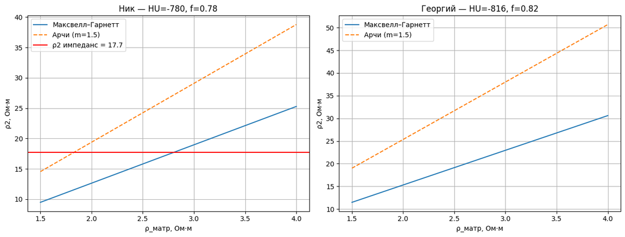

```
→ params/ct.json записан
```

**Допущения.** Наложение маски на срез служит визуальной проверкой корректности сегментации.

[figure not shown]

**Анализ результатов.** Ячейка выводит срез с маской; при выполнении позволяет убедиться, что выделено именно лёгкое.

**Результаты и умозаключения.** Сегментация признаётся корректной, если маска покрывает лёгочную ткань без захвата средостения и грудной стенки.

## §4. Выводы

Дальше — геометрический `L_max` по КТ (межрёберное расстояние, кривизна) для верхней границы применимости (§2.5).